# A4: Incarceration

## Name: Reagan Ince

### Introduction

As I explore trends related to crime, particularly the rates and stratification among racial groups throughout the United States, it is critical to gain a more in-depth understanding of the variables, namely those related to time, race, incarceration rate, arrest/jailed rate, gender, among others. These are critical to examine to gain insights on the forces that shape our contemporary understanding of differences that manifest across race and gender. It is crucial to grow in our understanding of these areas in order to begin to remedy many of the disproportionate impacts faced by people of color in our criminal justice system.

### Summary Information

As I reflect on the data set focusing on crime rates, themes that I found most critical to highlight surround the discrepancy between different groups, namely differences among race, gender, location, etc.

The questions I asked are as follows: 1) What is the average value of those jailed across all the counties per year? 2) What is year has the highest incarceration rate? (prison) 3) What is the rate of male v. female incarceration? (prison) 4) What is the which state has the highest rate of incarceration? 5) What race is subjected to the highest incarceration rate?

As I explored the answers to this question, I found that the average values of those jailed across all the counties per year begins at 64,951 and increases each year. Within this, I also found that 2007 is the year with the highest incarceration rate at 0.00413. Prison populations also tend to be primarily male, with a rate of male:female inmates in 2016 to be 1316:156. It was also found that Texas is the state with the highest rate of incarceration, and black people have the highest rate of incarceration. None of these findings particularly surprise me, rather it confirms many of the trends I have noticed in the larger socio-political network.

```r
source("./summary.R")
```

```
## [1] "Average jail population per year: "
## # A tibble: 49 × 2
##     year average_jail_pop
##    <int>            <dbl>
##  1  1970           64951.
##  2  1971           65852.
##  3  1972           66634.
##  4  1973           67294.
##  5  1974           67926.
##  6  1975           68600.
##  7  1976           69267.
##  8  1977           69967.
##  9  1978           70710.
## 10  1979           71498.
## # ℹ 39 more rows
##
##
## [1] "Year with the highest incarceration rate: "
## # A tibble: 1 × 2
##    year incarceration_rate
##   <int>              <dbl>
## 1  2007            0.00413
##
##
## [1] "Prison Population by Gender Rates: "
## # A tibble: 49 × 3
##     year male_incarceration_rate female_incarceration_rate
##    <int>                   <dbl>                     <dbl>
##  1  1970                    462.                      2.07
##  2  1971                    551.                      5.66
##  3  1972                    533.                      6.18
##  4  1973                    564.                      6.80
##  5  1974                    624.                     11.3
##  6  1975                    669.                     13.4
##  7  1976                    651.                     13.9
##  8  1977                    698.                     20.8
##  9  1978                    647.                     20.2
## 10  1979                    689.                     23.9
## # ℹ 39 more rows
##
##
## [1] "The state with the highest incarceration: "
## [1] "TX"
##
##
## [1] "The race with the highest incarceration: "
## [1] "total_black_incarceration_rate"
```

### The Dataset

This data was collected by the Vera Institute of Justice. They generated this data by using data from the Bureau of Justice Statistics (BJS) collections: the Census of Jails (COJ), which encapsulates all jails and is conducted every five to eight years since 1970, and the Annual Survey of Jails (ASJ), which encapsulates about one-third of jails-and includes nearly all of the largest jails-that has been conducted in non-census years since 1982. They similarly drew from the BJS National Corrections Reporting Program (NCRP). These two data sets were based in jail/prison record maintenance and census data.

This data was collected in order to create additional robustness to data that allows researchers to draw conclusions about county level aspects of the data, rather than working at the state/country scale that other datasets require.

Although I used various data sets in calculating this information, the one that includes most of the information I used in this analysis is prison_jail_rate_since_1990.

- This data includes 23 features (columns) and 91,031 observations (rows).

When working with this data, and considering potential ethical limitations, it is critical to examine the larger context in which this information is being collected as well as potential errors that might have been committed in collecting this information. Within the US’s criminal justice system, there are disproportionate numbers of people of color, as well as other marginalized identities. While this is a potential ethical limitation, it also presents as an issue with data processing as the collected information is skewed depending on the goals of the project.

### Trends Over Time Chart

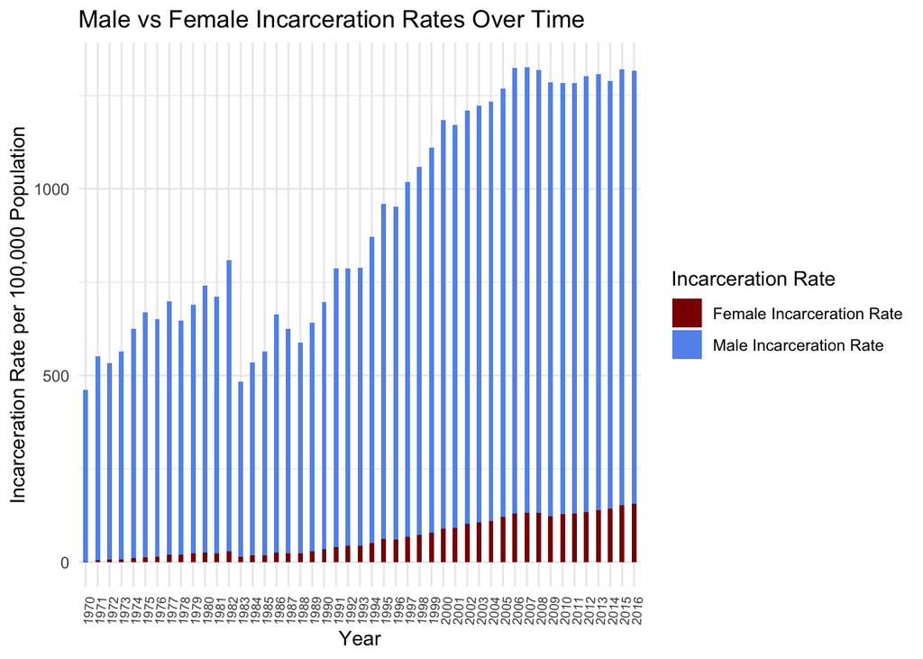

### Variable Comparison Chart

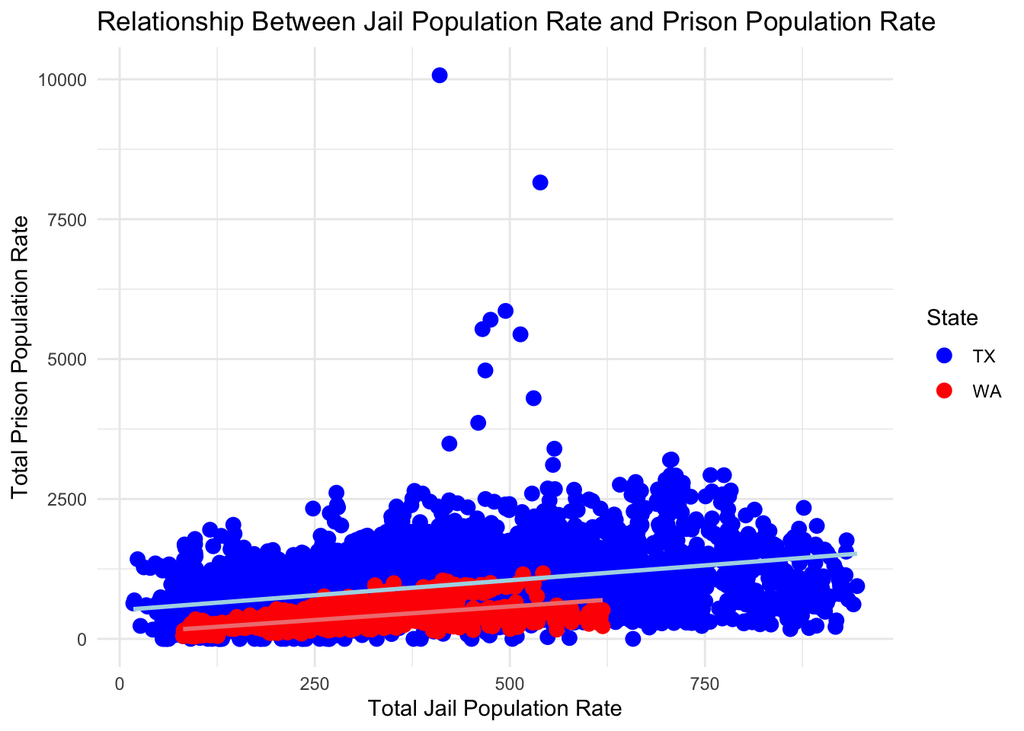

### Map

This map provides an overview of the black incarceration rate across the United States. This provides insights on the geographical distribution of disproportionate punishment against people of color, particularly considering longstanding practices of discrimination and segregation in certain areas, which is reflected in the map. Patterns that emerged through this graph highlight the higher incarceration rate in states that implement vagrancy laws or similar laws that work to criminalize people based on their status. This can be seen through the criminalization of immigration, poverty, homelessness, etc., all which often intersect. States that have higher incarceration rates of black people are also those that have policies and laws reflective of these trends.

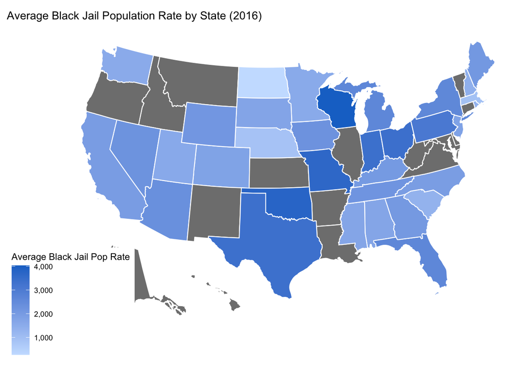